# Clustering of Hi-C contact maps

Shubham Chaturvedi, Pierre Neuvial, Nathalie Vialaneix

2025-11-19

```r
# IMPORTANT: this vignette can not be created if HiTC is not installed
if (!require("HiTC", quietly = TRUE)) {
  knitr::opts_chunk$set(eval = FALSE)
}
```

# Introduction

Hi-C is a sequencing-based molecular assay designed to measure intra and inter-chromosomal interactions between the DNA molecule. In particular, the identification of Topologically-Associated Domains (TADs), that is, of regions of the genome in which physical interactions are frequent, provides insight into the three-dimensional organization of a genome [2].

```r
library("adjclust")
```

# Loading and displaying a sample Hi-C contact map

The data set `hic_imr90_40_XX` is an object of class `HTCexp` which has been obtained from the `HiTC` package [4]. It is a contact map corresponding to the first 500 x 500 bins on chromosome X vs chromosome X.

```r
load(system.file("extdata", "hic_imr90_40_XX.rda", package = "adjclust"))
```

The script used to create this map can be found by executing the following command:

```r
system.file("system/create_hic_chrXchrX.R", package="adjclust")
```

```
## [1] "/tmp/RtmpKXPwXI/Rinst558ea27653c5f/adjclust/system/create_hic_chrXchrX.R"
```

Now we have a look at the data.

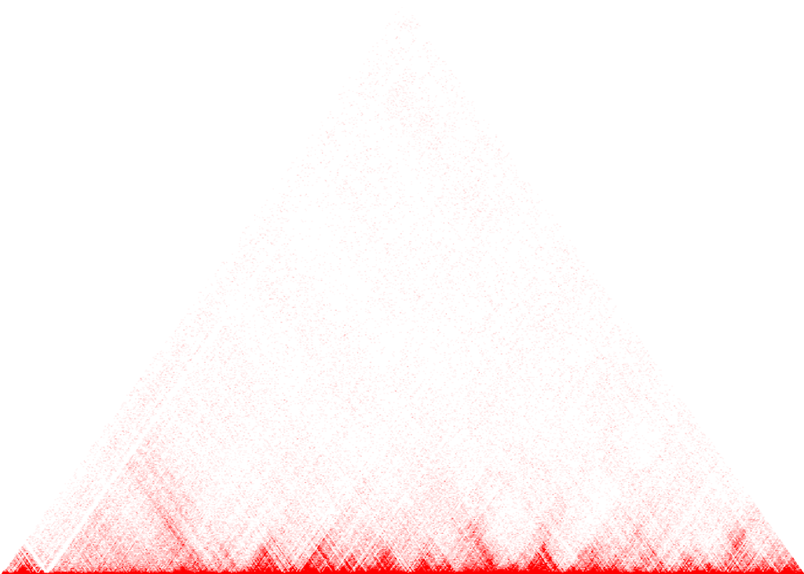

```r
HiTC::mapC(hic_imr90_40_XX)
```

# Using `hicClust`

`hicClust` operates directly on objects of class `HTCexp`

```r
fit <- hicClust(hic_imr90_40_XX)
```

```r
binned <- HiTC::binningC(hic_imr90_40_XX, binsize = 1e5)
fitB <- hicClust(binned)
fitB
```

```
##
## Call:
## hicClust(binned)
##
## Cluster method   : hicClust
## Number of objects: 205
```

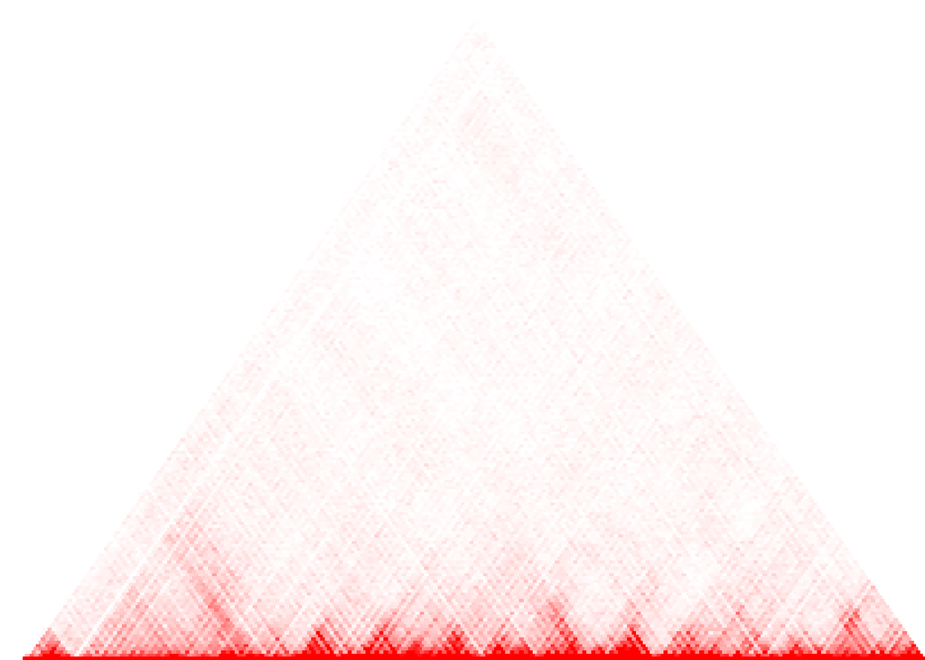

```r
HiTC::mapC(binned)
```

The output is of class `chac`. In particular, it can be plotted as a dendrogram silently relying on the function `plot.dendrogram`:

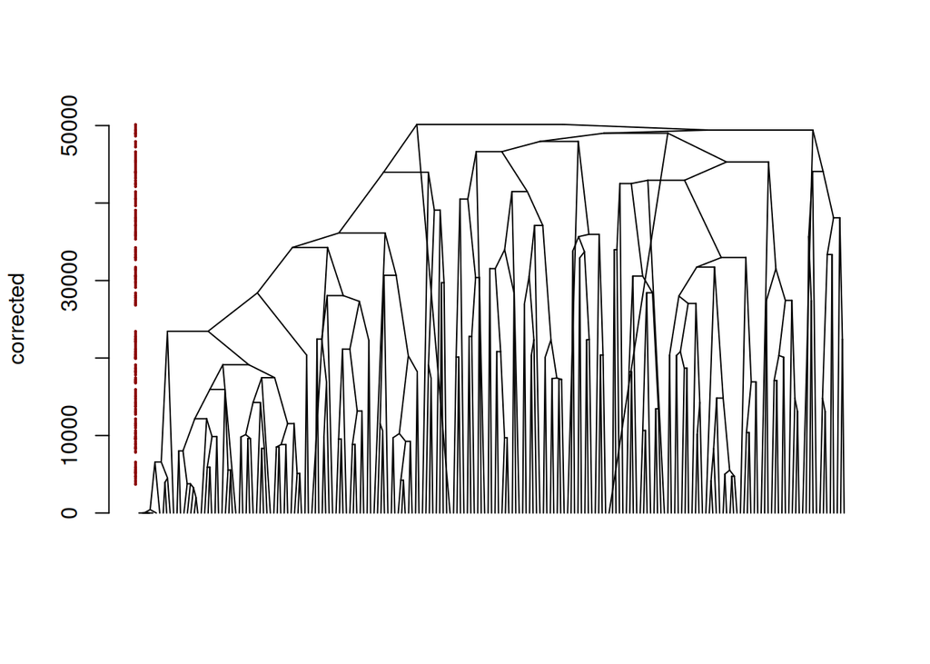

```r
plot(fitB, mode = "corrected")
```

Moreover, the output contains an element named `merge` which describes the successive merges of the clustering, and an element `gains` which gives the improvement in the criterion optimized by the clustering at each successive merge.

```r
head(cbind(fitB$merge, fitB$gains))
```

[output not shown]

# Other types of input

Contacts maps can also be stored as objects of class `Matrix::dsCMatrix`, or as plain text files. These types of input are also accepted as first argument to `hicClust`.

# References

[1] Ambroise C., Dehman A., Neuvial P., Rigaill G., and Vialaneix N. (2019). Adjacency-constrained hierarchical clustering of a band similarity matrix with application to genomics. *Algorithms for Molecular Biology*, **14**, 22.

[2] Dixon J.R., *et al* (2012). Topological domains in mammalian genomes identified by analysis of chromatin interactions. *Nature*, **485**(7398), 376.

[3] Randriamihamison N., Vialaneix N., and Neuvial P. (2021). Applicability and interpretability of Ward’s hierarchical agglomerative clustering with or without contiguity constraints. *Journal of Classification*, **38**, 363–389.

[4] Servant N., *et al* (2012). HiTC: Exploration of High-Throughput ‘C’ experiments. *Bioinformatics*, **28**(21), 2843-2844.